# Bird Strikes on AirCraft Analysis by Group 5

Mingxi Li (li.mingxi1@northeastern.edu)

Si Wu (wu.si3@northeastern.edu)

Zheng Zheng (zheng.zheng2@northeastern.edu)

Jiawei Zhou (zhou.jiaw@northeastern.edu)

## 0.1 Introduction

Bird strikes have been a matter of concern for the aviation industry since its inception. These events, which refer to the collision of a bird with an aircraft, can result in substantial financial losses and potential risks to safety. As the aviation industry grows, understanding and mitigating bird strikes becomes more crucial, especially considering the rise in global air traffic.

In this project, our group - Group 5, dives deep into the data related to bird strikes.Our primary aim is to analyze the patterns of bird strikes on aircrafts across different years, especially focusing on various flight phases. By doing so, we hope to identify high-risk factors and periods associated with these incidents.”

With this analysis, we hope to contribute valuable insights that can assist airlines, pilots, and airport authorities in understanding the dynamics of bird strikes better. Our findings might pave the way for innovative solutions to tackle this persistent challenge in the aviation industry.

Source data: FAA[1] The data for our analysis is sourced from a comprehensive database that logs bird strikes on aircrafts. This database provides detailed insights on the various factors and conditions under which these incidents occur, making it a rich source for our study

## 0.2 Build ERD Model and Relational Schema

1. The conceptual model as a Crow’s Foot ERD - Zheng Zheng

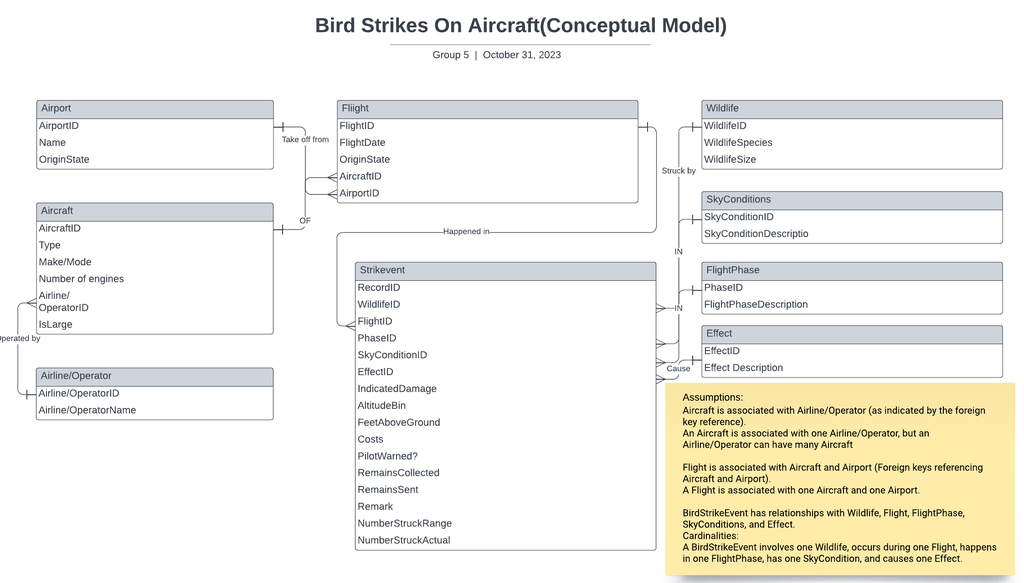

2. The logical model as a Crow’s Feet Relational Schema - Zheng Zheng

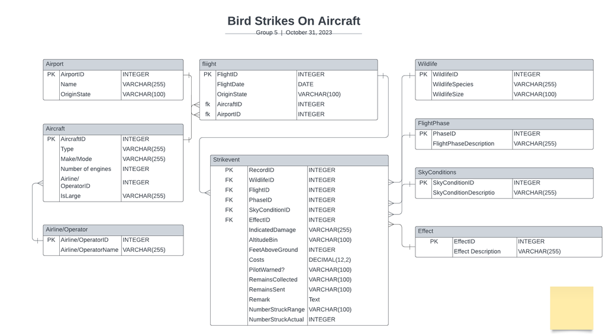

## 0.4 Load the Bird Strikes CSV file into R and populate the tables with the data.

```r
names(csv_data) <- c(
  "RecordID",
  "Type",
  "AirportName",
  "AltitudeBin",
  "Make_Model",
  "NumberStruckRange",
  "NumberStruckActual",
  "EffectDescription",
  "FlightDate",
  "IndicatedDamage",
  "NumberOfEngines",
  "Airline_OperatorName",
  "OriginState",
  "FlightPhaseDescription",
  "Precipitation",
  "RemainsCollected",
  "RemainsSent",
  "Remarks",
  "WildlifeSize",
  "SkyConditionDescription",
  "WildlifeSpecies",
  "PilotWarned",
  "Costs",
  "FeetAboveGround",
  "NumberOfPeopleInjured",
  "IsLarge"
)
```

```r
# Aircraft Table
csv_data$Type <- as.character(csv_data$Type)
csv_data$Make_Model <- as.character(csv_data$Make_Model)
csv_data$NumberOfEngines <- as.integer(as.character(csv_data$NumberOfEngines))
csv_data$IsLarge <- as.character(csv_data$IsLarge)

# Airport Table
csv_data$AirportName <- as.character(csv_data$AirportName)

# Flight Table
csv_data$FlightDate <- as.Date(csv_data$FlightDate, format="%m/%d/%Y")
csv_data$OriginState <- as.character(csv_data$OriginState)

# FlightPhase Table
csv_data$FlightPhaseDescription <- as.character(csv_data$FlightPhaseDescription)

# SkyConditions Table
csv_data$SkyConditionDescription <- as.character(csv_data$SkyConditionDescription)

# Wildlife Table
csv_data$WildlifeSpecies <- as.character(csv_data$WildlifeSpecies)
csv_data$WildlifeSize <- as.character(csv_data$WildlifeSize)

# BirdStrikeEvent Table
csv_data$AltitudeBin <- as.character(csv_data$AltitudeBin)
csv_data$FeetAboveGround <- as.integer(as.character(csv_data$FeetAboveGround))
csv_data$NumberOfPeopleInjured <- as.integer(as.character(csv_data$NumberOfPeopleInjured))
csv_data$Costs <- as.numeric(as.character(csv_data$Costs))
csv_data$PilotWarned <- as.character(csv_data$PilotWarned)
csv_data$RemainsCollected <- as.character(csv_data$RemainsCollected)
csv_data$RemainsSent <- as.character(csv_data$RemainsSent)
csv_data$Remarks <- as.character(csv_data$Remarks)
csv_data$NumberStruckRange <- as.character(csv_data$NumberStruckRange)
csv_data$NumberStruckActual <- as.integer(as.character(csv_data$NumberStruckActual))
csv_data$IndicatedDamage <- ifelse(csv_data$IndicatedDamage == 'Caused damage', 1, 0)

# Effect Table
csv_data$EffectDescription <- as.character(csv_data$EffectDescription)

# Airline/Operator Table
csv_data$Airline_OperatorName <- as.character(csv_data$Airline_OperatorName)
```

```r
# Identify columns with categorical data
categorical_cols <- c(
  "Type", "AirportName", "AltitudeBin", "Make_Model", "EffectDescription",
  "OriginState", "FlightPhaseDescription", "Precipitation", "RemainsCollected",
  "RemainsSent", "Remarks", "WildlifeSize", "SkyConditionDescription", "WildlifeSpecies",
  "PilotWarned", "IsLarge", "Airline_OperatorName", "NumberStruckRange"
)

# Replace NA values with 'Unknown' for these columns
csv_data[categorical_cols] <- lapply(csv_data[categorical_cols], function(col) {
    ifelse(is.na(col)| col == "", 'Unknown', col)
})

# Identify columns with numerical data
numerical_cols <- c(
  "RecordID", "NumberStruckActual", "NumberOfEngines", "Costs",
  "FeetAboveGround", "NumberOfPeopleInjured"
)

# Replace 'Unknown' or other non-date values in FlightDate with '1900-01-01'
csv_data$FlightDate[csv_data$FlightDate == ""  | !grepl("^\\d{4}-\\d{2}-\\d{2}$", csv_data$FlightDate)] <- '1900-01-01'

# Replace NA values with 0 for these columns
csv_data[numerical_cols] <- lapply(csv_data[numerical_cols], function(col) {
    ifelse(is.na(col)| col == "", 0, col)
})
```

```r
# Airline/Operator IDs
airline_operator_ids <- unique(csv_data$Airline_OperatorName)
airline_operator_ids <- data.frame(Airline_OperatorID = seq_along(airline_operator_ids),
                                   Airline_OperatorName = airline_operator_ids)

# Aircraft IDs
aircraft_data <- unique(csv_data[, c("Type", "Make_Model", "NumberOfEngines", "Airline_OperatorName", "IsLarge")])
aircraft_data <- merge(aircraft_data, airline_operator_ids, by="Airline_OperatorName")
aircraft_data$AircraftID <- seq_along(aircraft_data$Type)

# Airport IDs
airport_ids <- unique(csv_data$AirportName)
airport_ids <- data.frame(AirportID = seq_along(airport_ids), AirportName = airport_ids)

# FlightPhase IDs
flight_phase_ids <- unique(csv_data$FlightPhaseDescription)
flight_phase_ids <- data.frame(PhaseID = seq_along(flight_phase_ids), FlightPhaseDescription = flight_phase_ids)

# SkyConditions IDs
sky_condition_ids <- unique(csv_data$SkyConditionDescription)
sky_condition_ids <- data.frame(SkyConditionID = seq_along(sky_condition_ids), SkyConditionDescription = sky_condition_ids)

# Wildlife IDs
wildlife_data <- unique(csv_data[, c("WildlifeSpecies", "WildlifeSize")])
wildlife_data$WildlifeID <- seq_along(wildlife_data$WildlifeSpecies)

# Effect IDs
effect_ids <- unique(csv_data$EffectDescription)
effect_ids <- data.frame(EffectID = seq_along(effect_ids), EffectDescription = effect_ids)

# Generating FlightID for each row in the csv_data dataframe
csv_data$FlightID <- seq(1, nrow(csv_data))
```

```r
# Merge Airline/Operator IDs
csv_data <- merge(csv_data, airline_operator_ids, by="Airline_OperatorName", all.x = TRUE)

# Merge Aircraft IDs
csv_data <- merge(csv_data, aircraft_data[, c("Type", "Make_Model", "NumberOfEngines", "Airline_OperatorID", "IsLarge", "AircraftID")],
                 by = c("Type", "Make_Model", "NumberOfEngines", "Airline_OperatorID", "IsLarge"), all.x = TRUE)

# Merge Airport IDs
csv_data <- merge(csv_data, airport_ids, by="AirportName", all.x = TRUE)

# Merge FlightPhase IDs
csv_data <- merge(csv_data, flight_phase_ids, by="FlightPhaseDescription", all.x = TRUE)

# Merge SkyConditions IDs
csv_data <- merge(csv_data, sky_condition_ids, by="SkyConditionDescription", all.x = TRUE)

# Merge Wildlife IDs
csv_data <- merge(csv_data, wildlife_data, by = c("WildlifeSpecies", "WildlifeSize"), all.x = TRUE)

# Merge Effect IDs
csv_data <- merge(csv_data, effect_ids, by="EffectDescription", all.x = TRUE)
```

```r
# Clear data from tables
dbGetQuery(con, "DELETE FROM BirdStrikeEvent")
dbGetQuery(con, "DELETE FROM Flight")
dbGetQuery(con, "DELETE FROM Wildlife")
dbGetQuery(con, "DELETE FROM SkyConditions")
dbGetQuery(con, "DELETE FROM FlightPhase")
dbGetQuery(con, "DELETE FROM Effect")
dbGetQuery(con, "DELETE FROM Aircraft")
dbGetQuery(con, "DELETE FROM Airport")
dbGetQuery(con, "DELETE FROM Airline_Operator")
```

```r
#1. Airline/Operator
for(i in 1:nrow(airline_operator_ids)) {
  query <- sprintf("INSERT INTO Airline_Operator (Airline_OperatorID, Airline_OperatorName) VALUES (%d, '%s')",
                   airline_operator_ids$Airline_OperatorID[i], airline_operator_ids$Airline_OperatorName[i])
  dbGetQuery(con, query)
}
```

```r
# Insert data into Airline/Operator
for(i in 1:nrow(aircraft_data)) {
  query <- sprintf("INSERT INTO Aircraft (AircraftID, Type, Make_Model, Number_of_Engines, Airline_OperatorID, IsLarge) VALUES (%d, '%s', '%s', %d, %d, '%s')",
                   aircraft_data$AircraftID[i], aircraft_data$Type[i], aircraft_data$Make_Model[i], aircraft_data$NumberOfEngines[i],
                   aircraft_data$Airline_OperatorID[i], aircraft_data$IsLarge[i])
  dbGetQuery(con, query)
}
```

```r
# Insert data into Airport
dbGetQuery(con, "DELETE FROM Airport")
escape_quotes <- function(string) {
  return(gsub("'", "''", string))
}

# Insert data into Airport
for(i in 1:nrow(airport_ids)) {
  airport_name_escaped <- escape_quotes(airport_ids$AirportName[i])
  query <- sprintf("INSERT INTO Airport (AirportID, AirportName) VALUES (%d, '%s')",
                   airport_ids$AirportID[i], airport_name_escaped)
  dbGetQuery(con, query)
}
```

```r
# 4. FlightPhase Table
for(i in 1:nrow(flight_phase_ids)) {
  query <- sprintf("INSERT INTO FlightPhase (PhaseID, FlightPhaseDescription) VALUES (%d, '%s')",
                   flight_phase_ids$PhaseID[i], flight_phase_ids$FlightPhaseDescription[i])
  dbGetQuery(con, query)
}
```

```r
# 5. SkyConditions Table
for(i in 1:nrow(sky_condition_ids)) {
  query <- sprintf("INSERT INTO SkyConditions (SkyConditionID, SkyConditionDescription) VALUES (%d, '%s')",
                   sky_condition_ids$SkyConditionID[i], sky_condition_ids$SkyConditionDescription[i])
  dbGetQuery(con, query)
}
```

```r
#6. Wildlife Table
escape_quotes <- function(string) {
  return(gsub("'", "''", string))
}

for(i in 1:nrow(wildlife_data)) {
  species_escaped <- escape_quotes(wildlife_data$WildlifeSpecies[i])
  size_escaped <- escape_quotes(wildlife_data$WildlifeSize[i])

  query <- sprintf("INSERT INTO Wildlife (WildlifeID, WildlifeSpecies, WildlifeSize) VALUES (%d, '%s', '%s')",
                   wildlife_data$WildlifeID[i], species_escaped, size_escaped)
  dbGetQuery(con, query)
}
```

```r
# Insert data into Flight table
for(i in 1:nrow(csv_data)) {
  query <- sprintf("INSERT INTO Flight (FlightID, FlightDate, OriginState, AircraftID, AirportID) VALUES (%d, '%s', '%s', %d, %d)",
                   csv_data$FlightID[i], csv_data$FlightDate[i], escape_quotes(csv_data$OriginState[i]), csv_data$AircraftID[i], csv_data$AirportID[i])
  dbGetQuery(con, query)
}
```

```r
#Insert the data into the Effect table
for(i in 1:nrow(effect_ids)) {
    query <- sprintf("INSERT INTO Effect (EffectID, EffectDescription) VALUES (%d, '%s')",
                     effect_ids$EffectID[i], effect_ids$EffectDescription[i])
    dbGetQuery(con, query)
}
```

```r
# Insert data into BirdStrikeEvent
sanitize_string <- function(input_string) {
  # Replace single quotes with two single quotes for SQL
  output_string <- gsub("'", "''", input_string)

  # Add more replacements as needed

  return(output_string)
}

# Apply the function to character columns in your dataframe
char_cols <- sapply(csv_data, is.character)
csv_data[char_cols] <- lapply(csv_data[char_cols], sanitize_string)

dbGetQuery(con, "DELETE FROM BirdStrikeEvent")
for(i in 1:nrow(csv_data)) {
  query <- sprintf("INSERT INTO BirdStrikeEvent (RecordID, WildlifeID, FlightID, PhaseID, SkyConditionID, EffectID, IndicatedDamage, AltitudeBin, FeetAboveGround, NumberOfPeopleInjured, Costs, PilotWarned, RemainsCollected, RemainsSent, Remark, NumberStruckRange, NumberStruckActual) VALUES (%d, %d, %d, %d, %d, %d, %d, '%s', %d, %d, %.2f, '%s', '%s', '%s', '%s', '%s', %d)",
                   csv_data$RecordID[i], csv_data$WildlifeID[i], csv_data$FlightID[i], csv_data$PhaseID[i], csv_data$SkyConditionID[i], csv_data$EffectID[i], csv_data$IndicatedDamage[i], csv_data$AltitudeBin[i], csv_data$FeetAboveGround[i], csv_data$NumberOfPeopleInjured[i], csv_data$Costs[i], csv_data$PilotWarned[i], csv_data$RemainsCollected[i], csv_data$RemainsSent[i], csv_data$Remarks[i], csv_data$NumberStruckRange[i], csv_data$NumberStruckActual[i])
  dbGetQuery(con, query)
}
```

## 0.5 Analysis Tasks - Si Wu and Jiawei Zhou

# 1 Create a SQL query against your database to find the number of bird strike incidents for each airline upon take-off or climb. Include all airlines. You may either use a {sql} code chunk or an R function to execute the query. It must be a single query.

```sql
SELECT
    ao.Airline_OperatorName AS Airline,
    COUNT(*) AS NumberOfIncidents
FROM
    BirdStrikeEvent bse
JOIN
    Flight f ON bse.FlightID = f.FlightID
JOIN
    Aircraft ac ON f.AircraftID = ac.AircraftID
JOIN
    Airline_Operator ao ON ac.Airline_OperatorID = ao.Airline_OperatorID
JOIN
    FlightPhase fp ON bse.PhaseID = fp.PhaseID
WHERE
    fp.FlightPhaseDescription IN ('Take-Off', 'Climb')
GROUP BY
    ao.Airline_OperatorName
ORDER BY
    NumberOfIncidents DESC;
```

```sql
SELECT AO.Airline_OperatorName AS Airline,
       SUM(CASE WHEN BE.PhaseID IN (1, 2) THEN 1 ELSE 0 END) AS BirdStrikeCount
FROM Airline_Operator AS AO
LEFT JOIN Aircraft AS A ON AO.Airline_OperatorID = A.Airline_OperatorID
LEFT JOIN Flight AS F ON A.AircraftID = F.AircraftID
LEFT JOIN BirdStrikeEvent AS BE ON F.FlightID = BE.FlightID
GROUP BY AO.Airline_OperatorName
ORDER BY BirdStrikeCount DESC;
```

```sql
SELECT *
FROM FlightPhase
;
```

#### 1.0.0.1 Create a SQL query against your database to find the airports that had the most bird strike incidents (during any flight phase). Include all airlines. You may either use a *{sql}* code chunk or an R function to execute the query. It must be a single query.

```sql
SELECT
    ap.AirportName AS Airport,
    COUNT(*) AS NumberOfIncidents
FROM
    BirdStrikeEvent bse
JOIN
    Flight f ON bse.FlightID = f.FlightID
JOIN
    Airport ap ON f.AirportID = ap.AirportID
GROUP BY
    ap.AirportName
ORDER BY
    NumberOfIncidents DESC;
```

#### 1.0.0.2 Create a SQL query against your database to find the number of bird strike incidents by year. Include all airlines. You may either use a *{sql}* code chunk or an R function to execute the query. It must be a single query.

```sql
SELECT
    YEAR(f.FlightDate) AS Year,
    COUNT(*) AS NumberOfStrikes
FROM
    Flight f
JOIN
    Aircraft a ON f.AircraftID = a.AircraftID
JOIN
    Airline_Operator ao ON a.Airline_OperatorID = ao.Airline_OperatorID
JOIN
    BirdStrikeEvent bse ON f.FlightID = bse.FlightID

WHERE
    YEAR(f.FlightDate) <> 1900
GROUP BY
    Year
ORDER BY
    Year;
```

# 2 Using the above data, build a column chart that visualizes the number of bird strikes incidents per year from 2008 to 2011 during take-off/climbing and during descent/approach/landing, so you can compare one versus the other. Adorn the graph with appropriate axis labels, titles, legend, data labels, etc.

```sql
SELECT
    YEAR(f.FlightDate) AS Year,
    fp.FlightPhaseDescription,
    COUNT(*) AS NumberOfIncidents
FROM
    BirdStrikeEvent bse
JOIN
    Flight f ON bse.FlightID = f.FlightID
JOIN
    FlightPhase fp ON bse.PhaseID = fp.PhaseID
WHERE
    YEAR(f.FlightDate) BETWEEN 2008 AND 2011
    AND fp.FlightPhaseDescription IN ('Take-off', 'Climbing', 'Descent', 'Approach', 'Landing')
GROUP BY
    YEAR(f.FlightDate),
    fp.FlightPhaseDescription
HAVING
    fp.FlightPhaseDescription IN ('Take-off', 'Climbing', 'Descent', 'Approach', 'Landing')
ORDER BY
    YEAR(F.FlightDate), FP.FlightPhaseDescription;
```

```r
library(ggplot2)
library(DBI)

query <- "
SELECT
    YEAR(f.FlightDate) AS Year,
    fp.FlightPhaseDescription,
    COUNT(*) AS NumberOfIncidents
FROM
    BirdStrikeEvent bse
JOIN
    Flight f ON bse.FlightID = f.FlightID
JOIN
    FlightPhase fp ON bse.PhaseID = fp.PhaseID
WHERE
    YEAR(f.FlightDate) BETWEEN 2008 AND 2011
    AND fp.FlightPhaseDescription IN ('Take-off', 'Climbing', 'Descent', 'Approach', 'Landing')
GROUP BY
    YEAR(f.FlightDate),
    fp.FlightPhaseDescription
HAVING
    fp.FlightPhaseDescription IN ('Take-off', 'Climbing', 'Descent', 'Approach', 'Landing')
ORDER BY
    YEAR(F.FlightDate), FP.FlightPhaseDescription;
"

data <- dbGetQuery(con, query)

ggplot(data, aes(x=factor(Year), y=NumberOfIncidents, fill=FlightPhaseDescription)) +
  geom_bar(stat="identity", position="dodge") +
  labs(title="Bird Strike Incidents per Year (2008-2011)",
       x="Year",
       y="Number of Incidents") +
  scale_fill_brewer(palette="Set2") +
  theme_minimal()
```

[output not shown]

#### 2.0.0.1 Create a stored procedure in MySQL (note that if you used SQLite, then you cannot complete this step) that removes a bird strike incident from the database. You may decide what you need to pass to the stored procedure to remove a bird strike incident, *e.g.*, departure airport, airlines, or some ID. Show that the deletion worked as expected.

List a RecordID to future verification

```sql
SELECT * FROM BirdStrikeEvent WHERE RecordID = 1195;
```

Create a procedure table

```sql
CREATE PROCEDURE DeleteBirdStrikeEvent(IN incidentRecordID INT)
BEGIN
  DELETE FROM BirdStrikeEvent WHERE RecordID = incidentRecordID;
END
```

```sql
CALL DeleteBirdStrikeEvent(1195);
```

```sql
SELECT * FROM BirdStrikeEvent WHERE RecordID = 1195;
```

```r
# Close the connection
dbDisconnect(con)
```